# Práctica 1-D

Berros & Duarte & Rognon

September 2, 2018

Cargamos algunas librerías útiles:

```r
library("tidyverse")
library("here")
library("glue")
```

Consignas:

> Generar n = 100 muestras de una variable aleatoria ε(λ) con λ = 1 y graficar su distribución empı́rica junto con la función de distribución acumulada.

> Para las 100 muestras obtenidas en la parte a), calcular el estimador de λ por el método de los momentos y por máxima verosimilitud.

> Proponer un estimador de la función de distribución acumulada distinto al obtenido en a) y graficarlo en el gráfico anterior. Qué observa? Mejora su propuesta la estimación dada en a)?

> Qué pasarı́a con las estimaciones anteriores si tuviéramos otro tamaño de muestra? Repita los puntos anteriores con n = 10 y n = 1000.

Generamos muestras aleatorias de una población con distribución exponencial, para diferentes valores de $n$ entre $10$ y $10000$ (cada $10$).

```r
simular <- function(tasa, n_) {
  df <-
    tibble(
      x = rexp(n_, rate = tasa),
      acumulada = pexp(x, rate = tasa)) %>%
    arrange(x) %>%
    rowid_to_column("i") %>%
    mutate(empirica = i / n_)

  ## Usé esto para comprobar que mi modo de calcular la distro empírica
  ## coincidía con el de R:
  # distribucion_empirica <- ecdf(df$x)
  # df <- mutate(df, empirica_R = map_dbl(x, distribucion_empirica))

  return (list(
    df = df,
    df_tidy = gather(df, key = "tipo", value = "probabilidad", -x, -i),
    muestra = df$x
  ))
}

TASA <- 1
simulaciones <- tibble(
  n_ = seq(10, 10e3, by = 10),
  simulacion = map(n_, ~simular(tasa = TASA, n_ = .)),
  muestra = map(simulacion, "muestra")
)
```

Graficamos la distribución empírica con $n \in \{10, 100, 1000\}$, junto a la función de distribución acumulada $\varepsilon(1)$:

```r
# Helper
extraer_simulacion <- function(n_elegido) {
  filter(simulaciones, n_ == n_elegido)[[1, "simulacion"]]
}
```

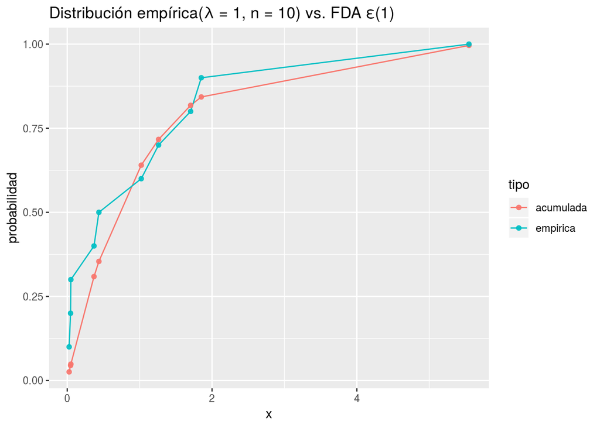

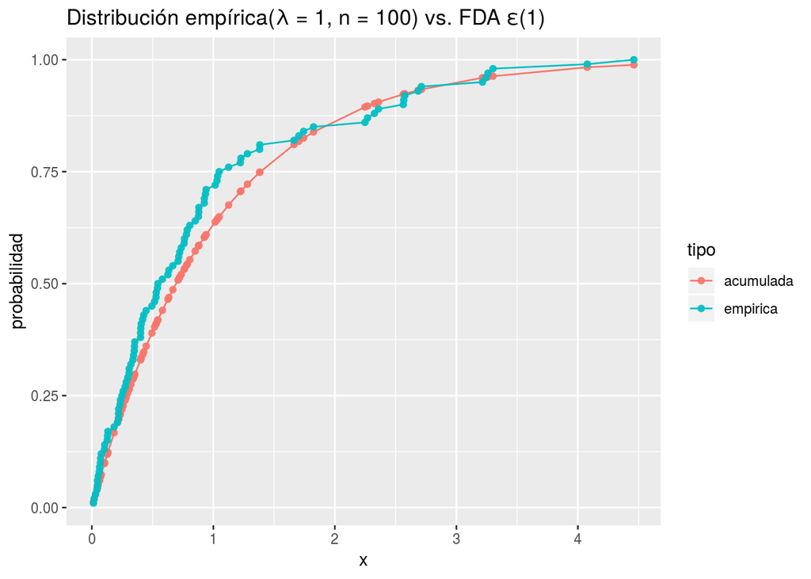

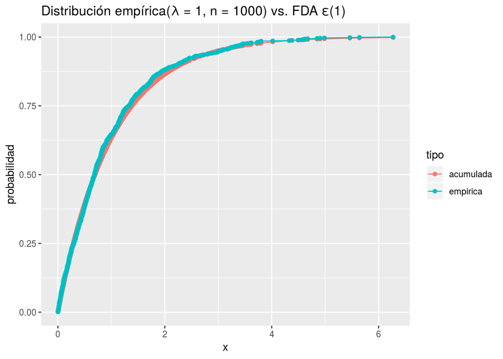

```r
graficar_simulacion <- function(n_elegido) {
  simulacion <- extraer_simulacion(n_elegido)
  fig <-
    simulacion$df_tidy %>%
    ggplot() +
    aes(x = x, y = probabilidad, color = tipo) +
    geom_line() +
    geom_point(alpha = .9) +
    labs(title = paste(glue("Distribución empírica(λ = {TASA}, n = {n_elegido})"),
                       glue("vs. FDA ε({TASA})"),
                       sep = " "))
  return (fig)
}

for (n_ in c(10, 100, 1000)) {
  fig <- graficar_simulacion(n_elegido = n_)
  ggsave(filename = here(glue("n{n_}_distribucion_empirica_vs_CDF.png")), fig)
  print(fig)
}
```

Estimamos $\lambda$ usando el método de los momentos y el estimador de máxima verosimilitud con las muestras del punto anterior.

```r
exp_estimador_momentos_1 <- function(X) {
  return (1/mean(X))
}

exp_estimador_momentos_2 <- function(X) {
  return (sqrt(2/mean(X^2)))
}

exp_estimador_maxver <- function(X) {
  return (1/mean(X)) # Obs: coincide con el EMOM-1
}

simulaciones <-
  simulaciones %>%
  mutate(
    emom1 = map_dbl(muestra, exp_estimador_momentos_1),
    emom2 = map_dbl(muestra, exp_estimador_momentos_2),
    emv = map_dbl(muestra, exp_estimador_maxver))
```

Estimadores obtenidos para $n = 10$:

- $\theta_{MOM1}$ = 0.812
- $\theta_{MOM2}$ = 0.706
- $\theta_{EMV}$ = 0.812

Estimadores obtenidos para $n = 100$:

- $\theta_{MOM1}$ = 1.089
- $\theta_{MOM2}$ = 1.059
- $\theta_{EMV}$ = 1.089

Estimadores obtenidos para $n = 1000$:

- $\theta_{MOM1}$ = 1.034
- $\theta_{MOM2}$ = 1.044
- $\theta_{EMV}$ = 1.034

Observación: El EMV coincide con el estimador basado en el primer momento.

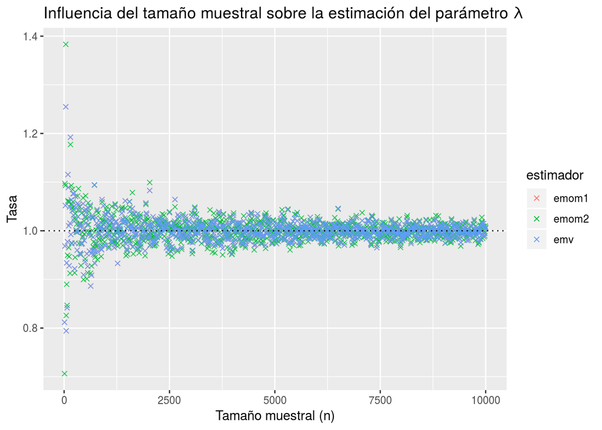

```r
simulaciones %>%
  select(-simulacion, -muestra) %>%
  gather(key = "estimador", value = "tasa", -n_) %>%
  ggplot() +
  aes(x = n_, y = tasa, color = estimador) +
  geom_point(shape = 4, alpha = .8) +
  geom_hline(yintercept = 1, linetype = 3) +
  labs(
    title = "Influencia del tamaño muestral sobre la estimación del parámetro λ",
    x = "Tamaño muestral (n)",
    y = "Tasa"
  ) +
  guides(color = guide_legend(override.aes = list(alpha = 1)))
```

Nota: EMV y EMOM1 se pisan siempre, de modo que aparecen como crucecitas color violeta en el gráfico.

Puede apreciarse que los estimadores se acercan al parámetro poblacional ($1$) a medida que la muestra se hace más grande.